# Loading Packages

We’ll need ggplot2, gridExtra and grid packages for the graphs

```r
library(ggplot2)
library(gridExtra)
library(grid)
```

# Importing the data

dThese are the columns we’re looking at

```r
columns <-
    c(
        "Overdue.Status",
        "Submission.Status",
        "Program.Element",
        "Dir",
        "Div",
        "Award.Number",
        "Award.Title",
        "Program.Officer",
        "Principal.Investigator",
        "PI.Email",
        "PI.ID",
        "Institution.Name",
        "Institution.ID",
        "Reporty.Type",
        "Report.Due.Date",
        "Report.Overdue.Date",
        "Program.Element.Code",
        "Start.Date",
        "End.Date"
    )
```

Load the data and set the levels for the Overdue.Status column so they’re time ordered

```r
rpts <-
    read.csv("Detailed Report.csv",
             col.names = columns,
             header = TRUE)
levels(rpts$Overdue.Status) <-
    c(
        "Due 0 - 45 Days",
        "Due 46 - 90 Days",
        "Due > 90 days",
        "Overdue 1 - 45 Days",
        "Overdue 46 - 90 Days",
        "Overdue > 90 days"
    )
```

First we want to create an NSF-wide plot that shows how many project reports are due and overdue. Start by creating the base plot usint the rpts data and telling it the Overdue.Status will be our x-axis data

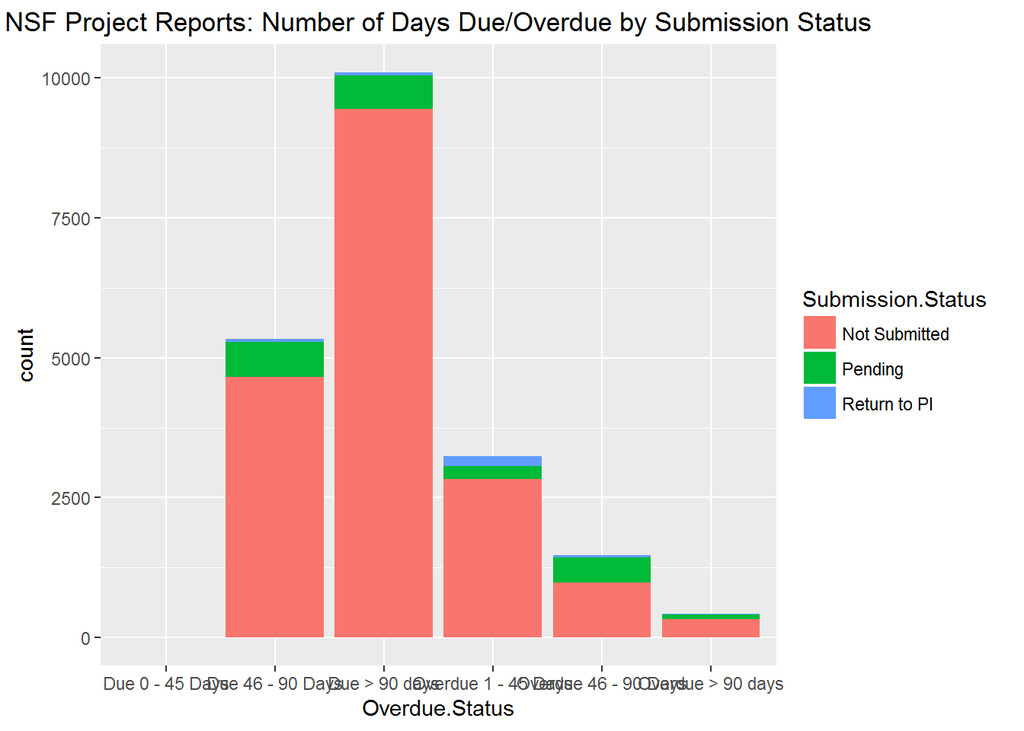

```r
plt <- ggplot(rpts, aes(x = Overdue.Status))
plt + geom_bar(aes(fill = Submission.Status)) +
    ggtitle("NSF Project Reports: Number of Days Due/Overdue by Submission Status")
```

The NSF-wide barchart motivates the question of how the reports are distrubuted accross directorates. Adding facet_wrap – which subsets the plot and displays the subset plots in a grid – does just that

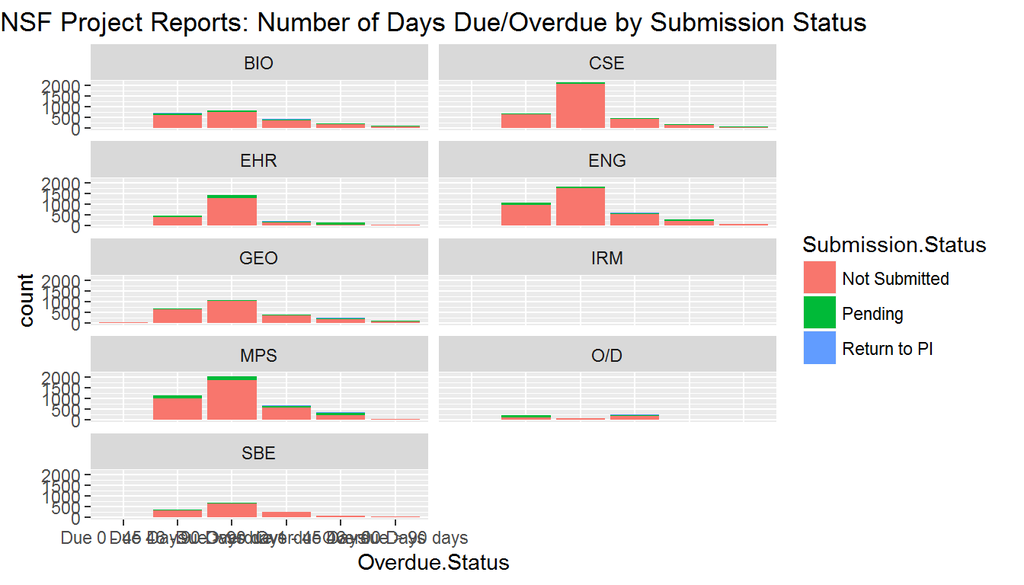

```r
plt + geom_bar(aes(fill = Submission.Status)) +
    ggtitle("NSF Project Reports: Number of Days Due/Overdue by Submission Status") + facet_wrap(~ Dir, ncol = 2)
```

Next we want to drop the IRM reports. If you want to see how many reports you’re dropping, The command below displays each division/directorate’s counts in a table table(rpts$Dir, rpts$Div) ‘Subset’ takes the dataframe and returns the observations that meet the condition provided. In this case, that the ‘Dir’ column doesn’t equal “IRM”

```r
rpts <- droplevels(subset(rpts, rpts$Dir != "IRM"))
```

[output not shown]